# Assignment 3

Neelima Cherukuri

2022-05-29

```r
library(ggplot2)
library(tidyverse)
library(scales)
library(dplyr)
```

Question 2 : Load the NYC Green Taxi Trip Records data into a data frame called tripdata_df. Inspect the data to identify its dimensions and the frequency of missing values. Helpful functions: dim(), glimpse() and summary(). Tip: it is also good practice to inspect the data type for each field/column to determine if the data was imported correctly.

```r
#Data
tripdata_df <- read.csv("C:\\Users\\neelc\\Downloads\\2018_Green_Taxi_Trip_Data.csv")
dim(tripdata_df)
```

```
## [1] 1048575      19
```

```r
glimpse(tripdata_df)
```

```
## Rows: 1,048,575
## Columns: 19
## $ VendorID              <int> 2, 2, 2, 2, 2, 2, 2, 2, 2, 2, 2, 2, 2, 2, 2, 1, …
## $ lpep_pickup_datetime  <chr> "1/1/2018 0:18", "1/1/2018 0:30", "1/1/2018 0:07…
## $ lpep_dropoff_datetime <chr> "1/1/2018 0:24", "1/1/2018 0:46", "1/1/2018 0:19…
## $ store_and_fwd_flag    <chr> "N", "N", "N", "N", "N", "N", "N", "N", "N", "N"…
## $ RatecodeID            <int> 1, 1, 1, 1, 1, 1, 1, 1, 1, 1, 1, 1, 1, 1, 1, 1, …
## $ PULocationID          <int> 236, 43, 74, 255, 255, 255, 189, 189, 129, 226, …
## $ DOLocationID          <int> 236, 42, 152, 255, 255, 161, 65, 225, 82, 7, 129…
## $ passenger_count       <int> 5, 5, 1, 1, 1, 1, 5, 5, 1, 1, 2, 2, 1, 1, 2, 1, …
## $ trip_distance         <dbl> 0.70, 3.50, 2.14, 0.03, 0.03, 5.63, 1.71, 3.45, …
## $ fare_amount           <chr> "6", "14.5", "10", "-3", "3", "21", "8.5", "14.5…
## $ extra                 <dbl> 0.5, 0.5, 0.5, -0.5, 0.5, 0.5, 0.5, 0.5, 0.5, 0.…
## $ mta_tax               <dbl> 0.5, 0.5, 0.5, -0.5, 0.5, 0.5, 0.5, 0.5, 0.5, 0.…
## $ tip_amount            <dbl> 0.00, 0.00, 0.00, 0.00, 0.00, 0.00, 0.00, 3.16, …
## $ tolls_amount          <dbl> 0, 0, 0, 0, 0, 0, 0, 0, 0, 0, 0, 0, 0, 0, 0, 0, …
## $ ehail_fee             <lgl> NA, NA, NA, NA, NA, NA, NA, NA, NA, NA, NA, NA, …
## $ improvement_surcharge <dbl> 0.3, 0.3, 0.3, -0.3, 0.3, 0.3, 0.3, 0.3, 0.3, 0.…
## $ total_amount          <chr> "7.3", "15.8", "11.3", "-4.3", "4.3", "22.3", "9…
## $ payment_type          <int> 2, 2, 2, 3, 2, 2, 2, 1, 2, 2, 2, 2, 2, 1, 1, 1, …
## $ trip_type             <int> 1, 1, 1, 1, 1, 1, 1, 1, 1, 1, 1, 1, 1, 1, 1, 1, …
```

```r
summary(tripdata_df)
```

```
##     VendorID     lpep_pickup_datetime lpep_dropoff_datetime store_and_fwd_flag
##  Min.   :1.000   Length:1048575       Length:1048575        Length:1048575
##  1st Qu.:2.000   Class :character     Class :character      Class :character
##  Median :2.000   Mode  :character     Mode  :character      Mode  :character
##  Mean   :1.827
##  3rd Qu.:2.000
##  Max.   :2.000
##
##    RatecodeID      PULocationID  DOLocationID   passenger_count
##  Min.   : 1.000   Min.   :  1   Min.   :  1.0   Min.   :0.000
##  1st Qu.: 1.000   1st Qu.: 49   1st Qu.: 61.0   1st Qu.:1.000
##  Median : 1.000   Median : 82   Median :129.0   Median :1.000
##  Mean   : 1.072   Mean   :110   Mean   :128.5   Mean   :1.359
##  3rd Qu.: 1.000   3rd Qu.:166   3rd Qu.:191.0   3rd Qu.:1.000
##  Max.   :99.000   Max.   :265   Max.   :265.0   Max.   :9.000
##
##  trip_distance     fare_amount            extra            mta_tax
##  Min.   :  0.000   Length:1048575     Min.   :-4.5000   Min.   :-0.5000
##  1st Qu.:  0.990   Class :character   1st Qu.: 0.0000   1st Qu.: 0.5000
##  Median :  1.700   Mode  :character   Median : 0.0000   Median : 0.5000
##  Mean   :  2.662                      Mean   : 0.3445   Mean   : 0.4882
##  3rd Qu.:  3.260                      3rd Qu.: 0.5000   3rd Qu.: 0.5000
##  Max.   :140.620                      Max.   : 4.5000   Max.   : 0.5000
##
##    tip_amount       tolls_amount      ehail_fee      improvement_surcharge
##  Min.   : -2.720   Min.   :  0.0000   Mode:logical   Min.   :-0.3000
##  1st Qu.:  0.000   1st Qu.:  0.0000   NA's:1048575   1st Qu.: 0.3000
##  Median :  0.000   Median :  0.0000                  Median : 0.3000
##  Mean   :  1.037   Mean   :  0.0858                  Mean   : 0.2932
##  3rd Qu.:  1.760   3rd Qu.:  0.0000                  3rd Qu.: 0.3000
##  Max.   :295.000   Max.   :557.5500                  Max.   : 0.3000
##
##  total_amount        payment_type     trip_type
##  Length:1048575     Min.   :1.000   Min.   :1.000
##  Class :character   1st Qu.:1.000   1st Qu.:1.000
##  Mode  :character   Median :1.000   Median :1.000
##                     Mean   :1.471   Mean   :1.018
##                     3rd Qu.:2.000   3rd Qu.:1.000
##                     Max.   :5.000   Max.   :2.000
##                                     NA's   :3
```

```r
#Missing values
tripdata_df$NA_frequency <- rowSums(apply (is.na (tripdata_df), 2, as.numeric))
tripdata_df$ehail_fee
```

[output not shown]

[output cut: 4153 more lines]

# Explanation:

#To inspect the data, we used dim, glimpse and summary functions to learn about the data. #Used is.na to find NA value frequency of the tripdata_df #Entire column of ehail_fee has missing values

Question 3 : Explore the data to determine if there are any inconsistent or invalid data; for example, examine the dates within the dataset to see if they align with your expectations. Identify at least Three (3) things that stand out to you and remember that this is based on your observations about the data, so it’s important to demonstrate what you found. (5pts)

Inspect the data and identify at least three columns/fields that should be represented as factors and convert their respective data types to a factor. Hint: make use of the data dictionary to understand the range of values for each field. (5pts)

```r
#3-I
a <- tripdata_df %>%
  count(DOLocationID, sort= TRUE)
head(a)
```

```
##   DOLocationID     n
## 1           74 36475
## 2           42 35328
## 3            7 33628
## 4           41 32009
## 5          129 28812
## 6          181 26881
```

```r
#3-II
b <- tripdata_df %>%
  count(PULocationID, sort= TRUE)
head(b)
```

```
##   PULocationID     n
## 1           74 65949
## 2           75 63527
## 3           41 59747
## 4            7 51513
## 5           82 46036
## 6          166 43292
```

```r
#3-III
summary(tripdata_df$tip_amount)
```

```
##    Min. 1st Qu.  Median    Mean 3rd Qu.    Max.
##  -2.720   0.000   0.000   1.037   1.760 295.000
```

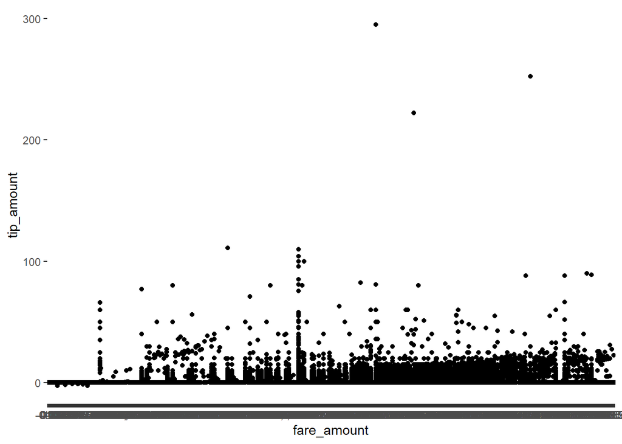

```r
ggplot (tripdata_df, aes(x= fare_amount, y= tip_amount)) +
  geom_point()
```

Question 4: Create a histogram, showing the trip_distance. Is the data skewed? Explain what you observed using 1-2 sentences. Note: you may need to rescale the y-axis using a log scale to improve the visualization. Remember that you can alter the data if needed

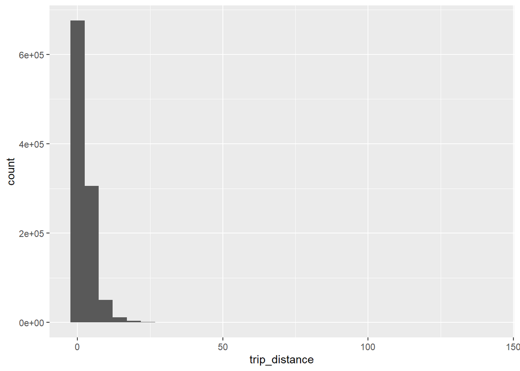

```r
ggplot(tripdata_df) +
  geom_histogram (mapping = aes(x = trip_distance), bins=30,)
```

```
## Warning: Transformation introduced infinite values in continuous y-axis
```

```
## Warning: Removed 12 rows containing missing values (geom_bar).
```

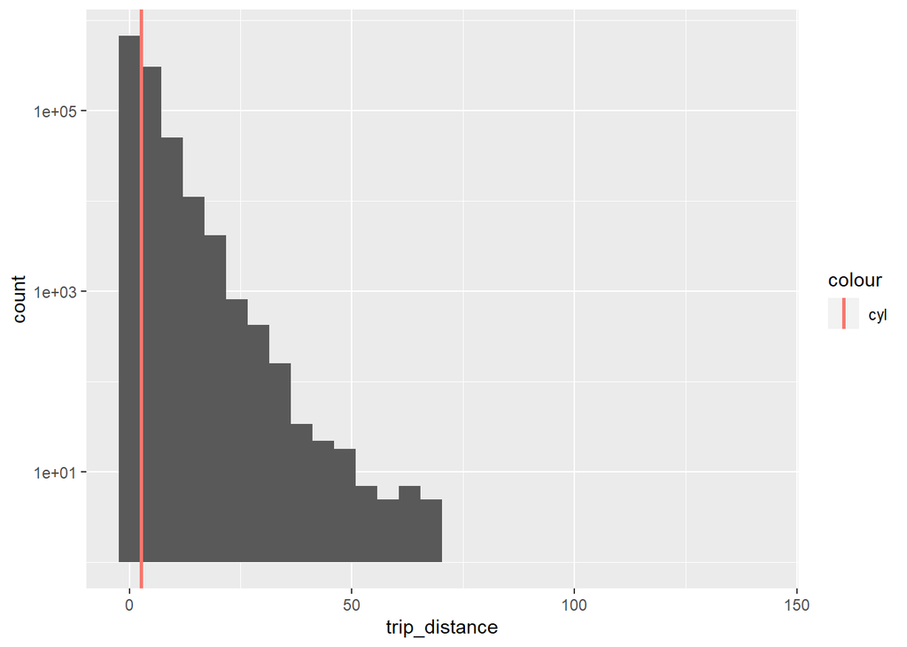

```r
ggplot(tripdata_df) +
  geom_histogram (mapping = aes(x = trip_distance), bins=30) +
  geom_vline(aes(xintercept = mean(trip_distance),colour = "cyl"), linetype = "solid", lwd = 1) +
  scale_y_log10()
```

Question 5: Analyze the tip_amount and trip_distance variables to identify any outliers. You can assume the outliers are 3 standard deviations from the mean. Comment on the outliers that were detected; after which, remove the outlier tip_amount from the data

```r
#Calculate mean, sd and z score
mean_df <- mean(tripdata_df$tip_amount)
sd_df <- sd (tripdata_df$tip_amount)
z_df <- abs((mean_df- tripdata_df$tip_amount)/ sd_df)
#Outliers are 3 z- scores away from either side of the mean
outliers <- tripdata_df[which(z_df >3),]
summary(outliers$tip_amount)
```

```
##    Min. 1st Qu.  Median    Mean 3rd Qu.    Max.
##   6.680   7.290   8.260   9.695  10.000 295.000
```

```r
#The below code removes outliers
abc <- tripdata_df[-which(z_df >3),]
dim (abc)
```

```
## [1] 1034131      20
```

```r
summary (abc$tip_amount)
```

```
##    Min. 1st Qu.  Median    Mean 3rd Qu.    Max.
## -2.7200  0.0000  0.0000  0.9165  1.7000  6.6600
```

Question:6 Filter the data from question 4 above, and create a suitable visualization to show the frequency of trips by payment_type (e.g. credit card, cash, etc). Ensure that your visualization(s) has a title and label both the x and y axis.

```r
abc <- abc %>%
  mutate (payment_type_label = fct_recode(factor(payment_type), "Credit card"="1",
                                  "Cash"="2",
                                   "No charge"="3",
                                   "Dispute"="4" ,
                                   "Unknown"= "5"))
abc %>%
count(payment_type_label)
```

```
##   payment_type_label      n
## 1        Credit card 549906
## 2               Cash 476994
## 3          No charge   5030
## 4            Dispute   2133
## 5            Unknown     68
```

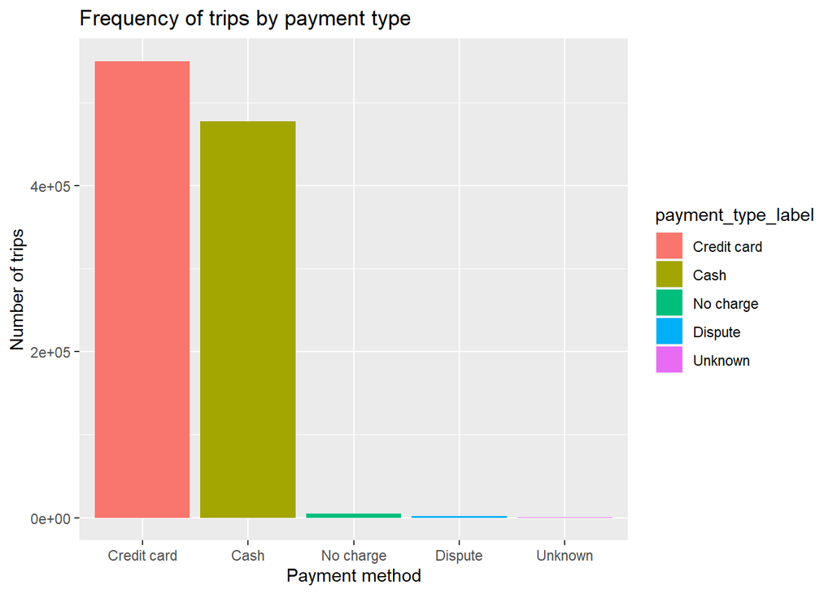

```r
ggplot(data= abc) +
  geom_bar(aes (x= payment_type_label, fill= payment_type_label))+
  ggtitle("Frequency of trips by payment type") +
  xlab("Payment method") + ylab("Number of trips")
```

Question 7:

State at least two methods/techniques that can be used to handle missing data. Which approach would you recommend, is suitable, to handle missing values in this dataset? How would you do this in R and provide examples on Taxi data.

Answer :

1. omit and na. exclude: returns the object with observations removed if they contain any missing values; differences between omitting and excluding NAs can be seen in some prediction and residual functions.
2. pass: returns the object unchanged.
3. fail: returns the object only if it contains no missing values.